[figure not shown]

# **Curso**

### Home

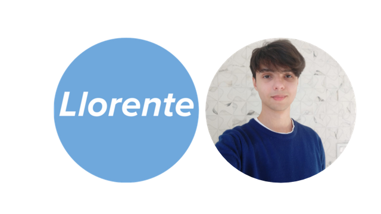

# *1. Descrição*

Fico grato por se interessar pelo curso. O fluxo de dados hodierno exige uma capacitação de manipulação dos mesmos para fins de: predição, interpretação, análises, entre outros. Este curso tem por objetivo promover a familiarização do interlocutor ao ambiente do RStudio, a fim de conhecer suas possibilidades. Irei trabalhar com processos básicos no R, como também processos Estatísticos inferenciais e descritivos, por meio de medidas quantitativas e amostrais. Com uma base teórica sólida, por meio do material, o aluno poderá aplicar habilidades necessárias para resolução de problemas práticos.

# *2. Conhecendo o R*

Para um desenvolvimento intuitivo com o curso, o interlocutor poderá instalar o R em seu dispositivo. **ATENÇÃO: é necessário instalar o R GUI primeiro, para assim instalar o RStudio!**

Identifique o seu Sistema Operacional. Após identificado, entre no link de acordo com o seu SO. Siga as instruções fornecidas para cada documentação, leia os termos de uso para assim instalar o R em seu dispositivo. Instale primeiro o R GUI e posteriormente o RStudio.

## *2.1 R GUI vs. RStudio*

Podemos encontrar algumas possibilidades para desenvolver os scripts em R. Dentre as possibilidades, encontramos o R GUI e o Rstudio. De modo geral, com vantagem sob o R GUI, o RStudio apresenta um ambiente totalmente amigável com informações organizadas, com falicidade de acesso para várias guias, entre outros. Por fim, usarei o RStudio, mas fique a vontade para utilizar qualquer um :)

[figure not shown]

## *2.2 Links*

**Windows**  
[R GUI](https://cran.r-project.org/bin/windows/base/)  
[RStudio](https://rstudio.com/products/rstudio/download/#download) (Open Source)  
**MAC**  
[R GUI](https://cran.r-project.org/bin/macosx/)  
[RStudio](https://rstudio.com/products/rstudio/download/#download) (Open Source)  
**Linux**  
Versões disponíveis até o momento (08/2020): Debian, Fedora, Ubuntu, Suse e Redhat.  
[R GUI](https://cran.r-project.org/bin/linux/)  
[RStudio](https://rstudio.com/products/rstudio/download/#download) (Open Source)

## *2.3 A interface do RStudio*

Com o RStudio aberto, encontramos seções divididas em 4 telas. Nelas encontramos o ambiente, onde podemos encontrar nossas variáveis, o histórico de cógidos e nossas conecxões. Já no suporte podemos encontrar todos os pacotes instalados no nosso dispotivo (irei comentar deles posteriormente :)), como também a visualização dos plots, do diretório e a aba “help”. Diretamente no console podemos executar códigos livremente, entretanto, sua comunicação e resposta é imediata ao apertar “enter” (não temos como visualizar e alterar um script de várias linhas). Por fim, no espaço de scripts é onde programamos todos os nossos códigos e afins, nele executamos o código selecionando ele e apertando Ctrl+ENTER.

[figure not shown]

## *2.4 Criando um R Notebook*

Para um visual mais limpo, podemos criar um `R Notebook`. Nele podemos dividir nossos códigos em blocos e executá-los separadamente. Para criar um basta ir em File>New File>R Notebook.

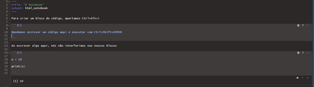

## *2.5 Declarando variáveis*

Durante a produção dos nossos códigos, constantemente precisaremos declarar valores e armazená-los em `variáveis`. São úteis para guardar resultados para futuras operações/manipulações e visualizações.

```r
x = 1 #Lê-se: x recebe 1
y <- 2 #Lê-se: y recebe 2
x #Visualizar a variável no console
```

```
## [1] 1
```

```r
print(y) #Visualizar a variável no console
```

```
## [1] 2
```

## *2.6 Pacotes*

### *2.6.1 Conhecendo os pacotes*

No [repositório do CRAN](https://cran.r-project.org/web/packages/available_packages_by_name.html) podemos encontrar vários pacotes que a comunidade disponibiliza.  
*Mas o que são pacotes?*

Quando trabalhamos com o R, geralmente precisamos de funcionalidades que tão além das funções nativas no próprio R. Justamente por esse motivo que há milhares de pacotes disponíveis no repositório! Tidyverse, dplyr, ggplot2, tidyr são alguns dos milhares de disponíveis. Recomendo que leia a documentação daquele que te interessar. É claro, não precisa ler sobre todos, mas se disponha a conhecer aqueles que te interessar :). Clique no [link](https://cran.r-project.org/web/packages/available_packages_by_name.html) para conhecer mais sobre os pacotes.

### *2.6.2 Utilizando os Pacotes*

Quando instalamos o RStudio, o mesmo já vem com alguns pacotes instalados nativamente. Esses pacotes ficam armazenados no diretório ondee você orientou na instalação para o realocar os repositórios.Para instalar um pacote, utilizamos o comando `install.packages("nome do pacote", dependencies = T)`, onde entre aspas é o nome do pacote, e `dependencies = TRUE` siginifica a instalação respectiva de possíveis dependências que um pacote possa ter. Essa é a maneira mais simples de instalar um pacote do repositório CRAN, para instalar pacotes do GitHub utilize a função `devtools::install_github()`.  
Ao necessitar da utilização do pacote, podemos carregá-lo ao momento em que precisamos utilizando a função `library(nome do pacote)` ou `require()`. A partir do momento em que você fechar o RStudio, seja pela função `close()` ou pelo “xzinho”, o pacote será descarregado. Podemos também, utilizar apenas uma função do pacote, caso a capacidade de memória seja limitada. Para isso utilizamos `nome_do_pacote::função()`. Caso necessitamos rodar um código dependente de um pacote, é usual utilizar: `if(!require(nome_do_pacote)) install.packages("nome_do_pacote")`  
E caso você precise saber a documentação de um pacote específico, basta utilizar o comando `browseVignettes()`, onde, entre parênteses, é passado o nome do pacote entre aspas.

## *2.7 Funções Básicas*

```r
help(mean) #Função ajuda
?mean #Função ajuda
#Ou apenas, pressione "F1"
citation() #Como citar o R em referências
ls() #Todas as variáveis decladaras
rm(a) #Remover uma varíavel
rm(list=ls()) #Remover todas as variáveis
getwd() #Diretório ativo no momento
setwd() #Alterar o diretório
```